# Intro to GIS

2021-08-31

## Before we Start

If you want to follow along with code and run the examples, you might want to view the workshop on a different device from your rstudio session. Hoppin is pretty resource hogging and will slow down your computations.

## Introductions

## About Me

- **name** : Kaz Sakamoto
- **email** : kaz@landeranalytics.com | k.sakamoto@columbia.edu
- **background** : Senior Data Scientist - Lander Analytics & Adjunct Assistant Professor Columbia University GSAPP
- **location** : Currently based out of Sacramento

## About You

- **name** :
- **background** :
- **location** :
- **GIS Experience** :
- **R Experience** :

## Agenda

- 09:00-10:00 Intro to GIS
- 10:00-11:00 Projections (CRS)
- 11:00-12:00 Cartography
- 12:00-12:30 Geoprocessing Tools
- 12:30-13:30 Lunch
- 13:30-14:00 Geoprocessing Tools
- 14:00-15:30 Spatial Stats
- 15:30-15:45 Break
- 15:45-17:00 Multi-criteria Decision Analysis + Map Algebra

## Brief History of Maps + GIS

## Ancient Maps

Why did humans create maps?

[figure not shown]

Imago Mundi: Babylonia 500 BCE

## Data + Maps

Can maps be used for insights?

[figure not shown]

Broad Street Cholrea Map - 1854

## Maps as a Service

What else can maps do for us?

[figure not shown]

Google Maps Routes

## Why Spatial Analysis?

## Why Spatial Analysis?

to measure important concepts:

**Distance, Adjacency, Interaction, Neighborhood**

or the 3Cs:

**Containment, Connectivity, Closeness**

## GIS

## What is GIS

[figure not shown]

## Another Definition

A GIS is a computer-based system to aid in the **collection, maintenance, storage, analysis, output, and distribution of spatial data and information.**

GIS allows us to define the **where** and **what** types of questions that we have.

## GIS Misconceptions

GIS is not only making maps, while the outputs are often maps this is not cartography.

Sometimes the outputs could be the attribute table.

## The Globe

[figure not shown]

This is a model of the Earth

## Geographic Data Models

The two most fundamental data models used in geographic data is the **vector** and **raster** formats.

- **Vector** data has dominated the social sciences since many features used tend to have discrete boundaries
- **Raster** is utilized most in environmental sciences since remote sensing data comes in as images which are more continuous in nature.

## Vector vs Raster

Here is an illustration of the vector and raster model compared to an image.

[figure not shown]

## Vectors

## Vectors - simple features

Open Geospatial Consortium(OGC) supported formats.

[figure not shown]

simple features

## Vector Representation

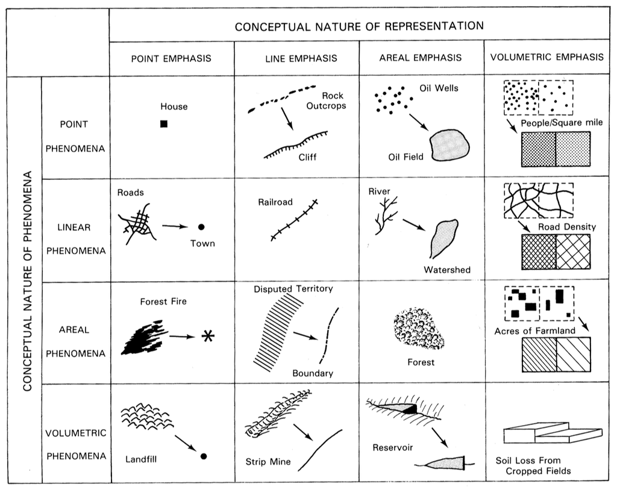

phenomena vs. Representation

## Topological Spatial Relations

[figure not shown]

## Raster

## Raster Data

[figure not shown]

## Satellite Imagery

[figure not shown]

## Layered Model

[figure not shown]

Layers of Geographic Data

## Maps - Territory

**A map is not the territory it represents, but, if correct, it has a similar structure to the territory, which accounts for its usefulness.** - *Alfred Korzybski*

**All models are wrong, but some are useful.** - *George Box*

## GIS Data

## Attribute Data

[figure not shown]

State Population Data

## Geometry Data

[figure not shown]

Spatial topology: representation and storage

## Digital GIS Formats

[GDAL](https://gdal.org/) - Geospatial Data Abstraction Library:

Can read over 200 different formats of data

- Esri Shapefile (shp)
- Geographic JavaScript Object Notation (GeoJSON)
- Google Keyhole Markup Language (KML/KMZ)
- GPS exchange Format (GPX)
- OpenStreetMap OSM XML
- GeoPackage (GPKG)

## sf package functions

all `st_` functions are similar to **PostGIS** functions and methods. It’s a standardized way of dealing with spatial data in DBs and outside to keep the user experience equivalent.

## sf classes

- **sf**: the table (data.frame) with feature attributes *and* feature geometries, which contains…
- **sfc**: the list-column with the geometries for *each feature* (record), which is composed of…
- **sfg**: the *feature geometry* of an individual simple feature.

## sf object

[figure not shown]

## Reading in Data

to load an sf object in R

```r
st_read(path)
```

## attribute table

to keep just the attribute table

```r
st_drop_geometry(sf_object)
```

## Exercise 1.1 Explore shapefile with sf

Reading in Shape files

## The “Bad News”

## Spatial Autocorrelation

Data from locations that are nearer in distance are more likely to be similar than those from afar. Similar with autocorrelation in date/time. We do have measures to calculate spatial autocorrelation such as Moran’s I, Geary’s C.

## MAUP

Spatial data are often made up from aggregates such as the census. Aggregation units such as census tracts or blocks are arbitrary with respect to the phenomena of study but can have a big effect in statistics. Think about gerrymandering districts to stack votes of one party.

## Gerrymandering

[figure not shown]

## Regression Strength

[figure not shown]

## Ecological Fallacy

is a formal fallacy in the interpretation of statistical data that occurs when inferences about the nature of individuals are deduced from inferences about the group to which those individuals belong.

Seeing that high levels of crime correlating with low income counties, doesn’t mean lower income individuals are more likely to commit crimes. You can see that it has commonalities with the MAUP where different levels of aggregation matters.

## Scale

The geographic scale at which the study is set is very crucial.

[figure not shown]

## Scale Matters

[figure not shown]

## Non-Uniformity

We can expect that areas with higher populations will have higher crime rates, because geographic space is non-uniform, we will expect patterns that reflect this. We may also see more plant species depending on the soil type in certain regions.

## Edge Effects

We also expect that areas in the city center will have observations on all sides, but boundaries that may have been created arbitrarily will only have neighbors towards the center. This is still a poorly understood area of study in GISc.

[figure not shown]